# Dataset Description:

# 15. Generate a dataframe which should include the "Player name", "Club Name", "Wage", and 'Overall rating'.

i) find the average Overall rating for each club.

ii) Display the average overall rating of Top10 Clubs using a plot

```python
player_info_df = df[['Name', 'Club', 'Wage', 'Overall']]
player_info_df.head()
```

|  | Name | Club | Wage | Overall |
| --- | --- | --- | --- | --- |
| 0 | L. Messi | FC Barcelona | 565000.0 | 94 |
| 1 | Cristiano Ronaldo | Juventus | 405000.0 | 94 |
| 2 | Neymar Jr | Paris Saint-Germain | 290000.0 | 92 |
| 3 | De Gea | Manchester United | 260000.0 | 91 |
| 4 | K. De Bruyne | Manchester City | 355000.0 | 91 |

```python
average_rating_per_club = player_info_df.groupby('Club')['Overall'].mean().reset_index()
print("The average Overall rating for each club:\n")
average_rating_per_club.head()
```

```
The average Overall rating for each club:
```

|  | Club | Overall |
| --- | --- | --- |
| 0 | SSV Jahn Regensburg | 65.586207 |
| 1 | 1. FC Heidenheim 1846 | 65.750000 |
| 2 | 1. FC Kaiserslautern | 63.384615 |
| 3 | 1. FC Köln | 70.785714 |
| 4 | 1. FC Magdeburg | 65.615385 |

```python
top_10_clubs = average_rating_per_club.sort_values(by='Overall', ascending=False).head(10)
print(top_10_clubs)
```

```
                    Club    Overall
326             Juventus  82.280000
398               Napoli  80.000000
315                Inter  79.750000
470          Real Madrid  78.242424
382                Milan  78.074074
212         FC Barcelona  78.030303
435  Paris Saint-Germain  77.433333
482                 Roma  77.423077
375    Manchester United  77.242424
504           SL Benfica  77.000000
```

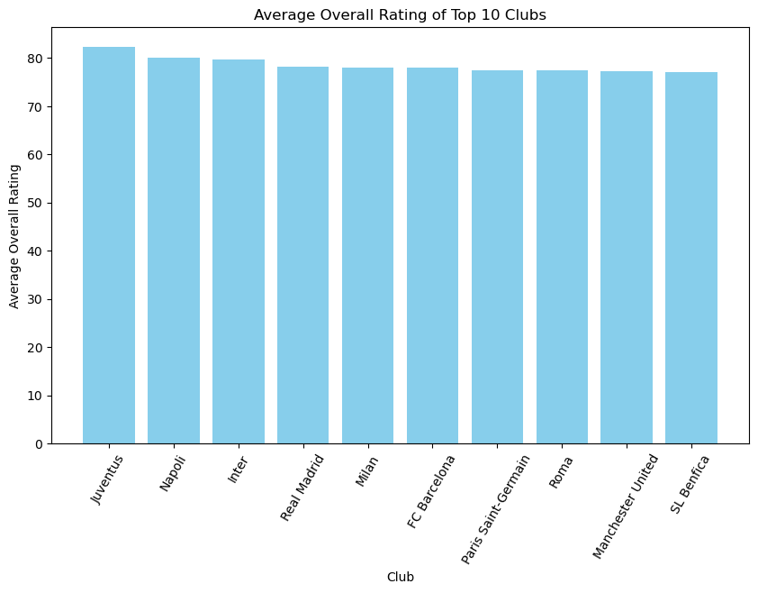

```python
 # Plot the average Overall rating of the Top 10 clubs
plt.figure(figsize=(10, 6))
plt.bar(top_10_clubs['Club'], top_10_clubs['Overall'], color='skyblue')
plt.title('Average Overall Rating of Top 10 Clubs')
plt.xlabel('Club')
plt.ylabel('Average Overall Rating')
plt.xticks(rotation=60)
plt.show()
```

16.What is the relationship between age and individual potential of the player? Visualize the relationship with appropriate plot and Comment on the same.

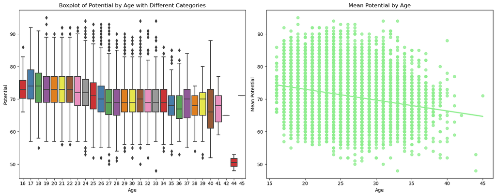

```python
plt.figure(figsize=(15, 6))

# Boxplot
plt.subplot(1, 2, 1)
sns.boxplot(x='Age', y='Potential', data=df, palette='Set1')
plt.title('Boxplot of Potential by Age with Different Categories')
plt.xlabel('Age')
plt.ylabel('Potential')

# Lineplot
plt.subplot(1, 2, 2)
sns.regplot(x='Age', y='Potential', data=df, marker='o', color='lightgreen')
plt.title('Mean Potential by Age')
plt.xlabel('Age')
plt.ylabel('Mean Potential')

plt.tight_layout()  # Adjust subplot parameters for better layout
plt.show()
```

1. Which features directly contribute to the wages of the players? Support your answer with a plot and a metric.

[output not shown]

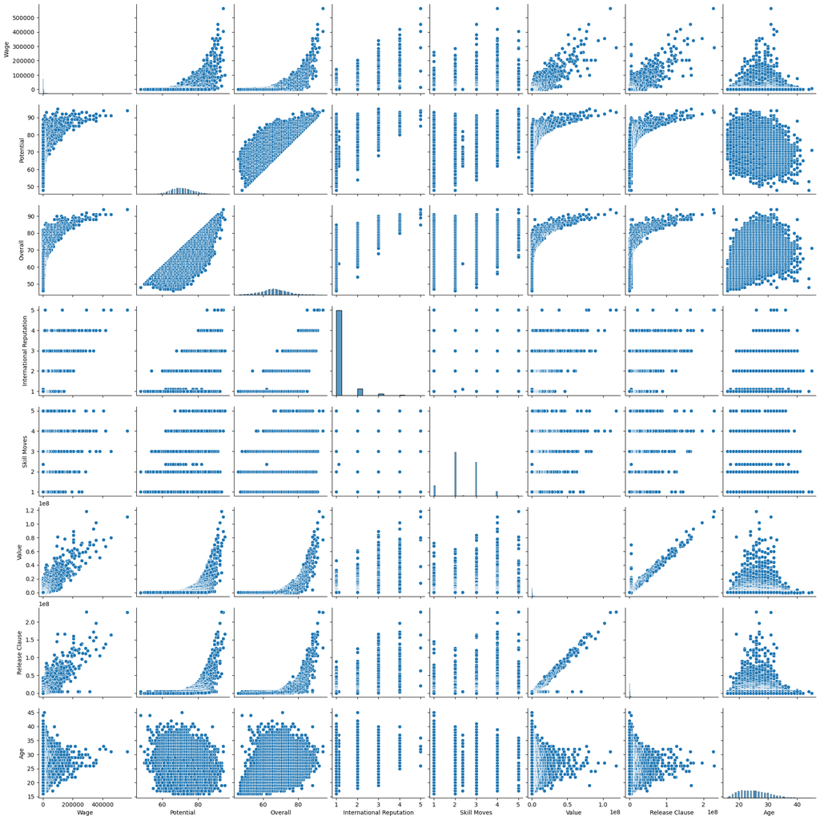

```python
pair_df = df[['Wage','Potential','Overall','International Reputation','Skill Moves','Work Rate','Value','Release Clause','Age']]

sns.pairplot(pair_df)
plt.show
```

```python
# # Plotting the heatmap to display correlation between the features

# plt.figure(figsize=(6, 6))
# sns.heatmap(wage_corr.to_frame(), cmap='viridis', annot=True, fmt='.2f', cbar=True)
# plt.title('Heatmap showing Correlation of Different Features with Player Wage')
# plt.show()
```

1. Find the position in the pitch where the maximum number of players play and the position where the minimum number of players play? Display it using a plot

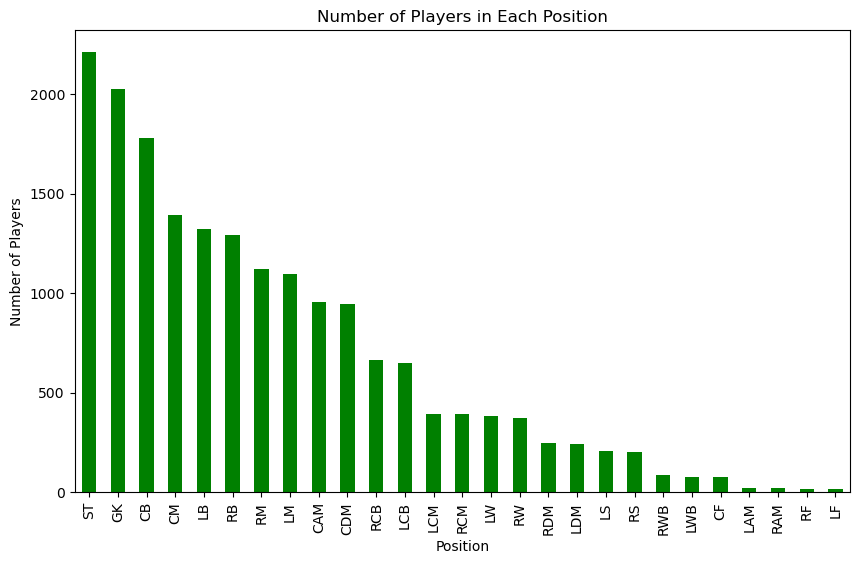

```
Position with the maximum number of players: ST
Position with the minimum number of players: LF
```

```python
import matplotlib.pyplot as plt

# Count the occurrences of each position
position_counts = df['Position'].value_counts()

# Find the position with the maximum count
max_position = position_counts.idxmax()

# Find the position with the minimum count
min_position = position_counts.idxmin()

# Plot the position counts
plt.figure(figsize=(10, 6))
position_counts.plot(kind='bar', color='green')
plt.title('Number of Players in Each Position')
plt.xlabel('Position')
plt.ylabel('Number of Players')
plt.xticks(rotation=90)
plt.show()

print(f"Position with the maximum number of players: {max_position}")
print(f"Position with the minimum number of players: {min_position}")
```

1. How many players are from the club 'Juventus' and the wage is greater than 200K? Display all the information of such players.

```python
juventus_df = df[(df['Club']=='Juventus') & (df['Wage']>200000.0)]
print('Players are from "Juventus" with wage is greater than 200K :')
juventus_df
```

```
Players are from "Juventus" with wage is greater than 200K :
```

[output not shown]

1. Generate a data frame containing top 5 players by Overall rating for each unique position.

```python
# Get count of unique positions in the dataset
distinct_positions = df['Position'].nunique()
print('Count of distinct positions: ',distinct_positions)
print('Data Frame row count: ',distinct_positions * 5)
sorted_df = df.sort_values(by = 'Overall', ascending = False).groupby('Position').head(5)
sorted_df = sorted_df.sort_values(by = ['Position','Overall'], ascending = [True,False]).reset_index(drop=True)
sorted_df[['Position','Name','Overall']]
```

```
Count of distinct positions:  27
Data Frame row count:  135
```

|  | Position | Name | Overall |
| --- | --- | --- | --- |
| 0 | CAM | A. Griezmann | 89 |
| 1 | CAM | C. Eriksen | 88 |
| 2 | CAM | M. Özil | 86 |
| 3 | CAM | T. Müller | 86 |
| 4 | CAM | Roberto Firmino | 86 |
| ... | ... | ... | ... |
| 130 | ST | Cristiano Ronaldo | 94 |
| 131 | ST | R. Lewandowski | 90 |
| 132 | ST | S. Agüero | 89 |
| 133 | ST | H. Kane | 89 |
| 134 | ST | G. Bale | 88 |

135 rows × 3 columns

1. What is the average wage one can expect to pay for the top 5 players in every position? (use the data frame created in Q19)

```python
sorted_df.groupby(['Position'])[['Wage']].mean()
```

| Position | Wage |
| --- | --- |
| CAM | 174000.0 |
| CB | 124800.0 |
| CDM | 199200.0 |
| CF | 47400.0 |
| CM | 130600.0 |
| GK | 192800.0 |
| LAM | 81600.0 |
| LB | 177200.0 |
| LCB | 162000.0 |
| LCM | 195400.0 |
| LDM | 138000.0 |
| LF | 123200.0 |
| LM | 169000.0 |
| LS | 130600.0 |
| LW | 261000.0 |
| LWB | 33000.0 |
| RAM | 46600.0 |
| RB | 155400.0 |
| RCB | 219000.0 |
| RCM | 257400.0 |
| RDM | 105000.0 |
| RF | 148000.0 |
| RM | 133000.0 |
| RS | 130400.0 |
| RW | 202000.0 |
| RWB | 44200.0 |
| ST | 294000.0 |